# Exercise 9.3

Manuela Giansante

2022-11-14

```r
# Download the needed libraries
library(data.table) #to read the data
library(caret) # to partition the data
library(kableExtra)# to create tables
library(ggplot2) # to make plots
library(gridExtra) # to organise the printing space for plots
library(forecast) # for the predict()
library(rpart) # to generate the regression trees
library(rpart.plot) # to plot the tree
```

```r
#setwd("C:/Users/Manu/Desktop/master course/data mining/data")
df <- fread("ToyotaCorolla.csv") #import the dataset
df2<- as.data.frame(df[,c("Price", "Age_08_04", "KM","Fuel_Type", "HP", "Automatic", "Doors", "Quarterly_Tax", "Mfr_Guarantee", "Guarantee_Period", "Airco", "Automatic_airco", "CD_Player", "Powered_Windows", "Sport_Model", "Tow_Bar")]) # filtered the dataset to the variables recommended by the book
```

Everything obeserved in the data in the previous exercise still stands.

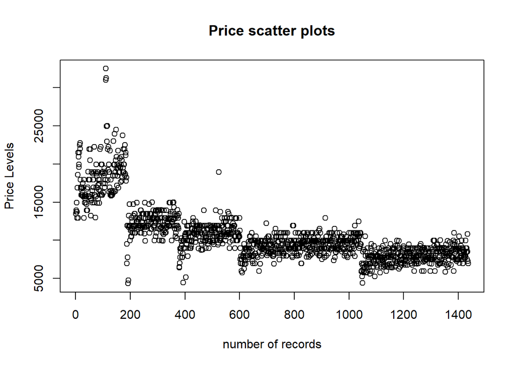

```r
plot(df2$Price, main="Price scatter plots", ylab="Price Levels", xlab= "number of records") #scatter plot of the outcome variable
```

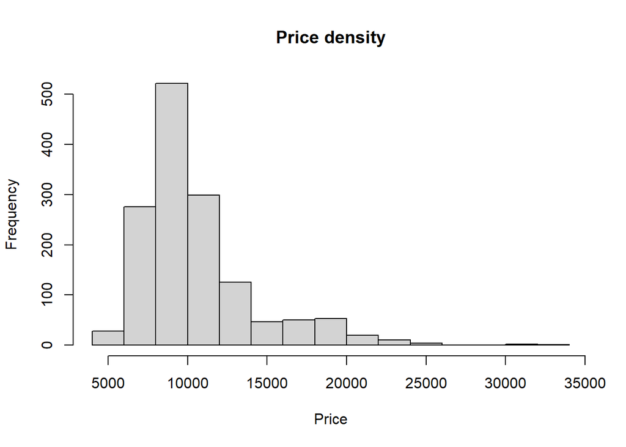

```r
hist(df2$Price, main= "Price density", xlab="Price") # histogram of the price of the used cars
```

In this case we will be doing a regression tree, so our estimates will be numerical, we are not classifying by a number of levels, for now. We look at the scatter plot, and we notice that the outcome variable is disposed in clusters of different volume, and the variable is skwed to the rigth around the mean.

We divide our dataset in training set and validation set:

```r
df$Fuel_Type = as.factor(df$Fuel_Type)# we set the fuel type as a factor

set.seed(1234)  # controlled random numbers, to have the same samples when we re-run the code
training<- sample(row.names(df2), 0.6*dim(df2)[1]) #  training set 50% of the data
validation  <- sample(setdiff(row.names(df2), training ),  0.4*dim(df2)[1]) # validation set 30%
train.df<- df2[training,] # training set as individual data.frame
valid.df<- df2[validation,] # validation set as individual data.frame
```

We are dividing the data-frame into training and validation set, in the previous exercise we set up dummies bc we needs variables with numerical records for some of the functions that were used. In this case we do not need that, so we only set the Fuel_Type as a factor.

## Full Grown Tree:

### 9.3.a

```r
set.seed(1234) # to make it replicable
toyota_tree<- rpart(Price  ~ ., data=train.df, method= "anova", minsplit=1, minbucket=1,cp=0.001, maxdepth=30) #cp is the cutoff by which splits are not attempted, if set to zero all splits will be attempted
options(scipen = 999) #scientific notation
print(toyota_tree, digits = 6)  # print estimations of the regression tree
```

```
## n= 861
##
## node), split, n, deviance, yval
##       * denotes terminal node
##
##   1) root 861 10191000000.0 10613.10
##     2) Age_08_04>=32.5 760  2718500000.0  9605.87
##       4) Age_08_04>=56.5 504   827834000.0  8713.32
##         8) Age_08_04>=68.5 232   246352000.0  7944.26
##          16) KM>=141869 16    20145400.0  6646.25 *
##          17) KM< 141869 216   197252000.0  8040.41
##            34) KM>=70303 137   104013000.0  7856.50 *
##            35) KM< 70303 79    80568300.0  8359.35 *
##         9) Age_08_04< 68.5 272   327228000.0  9369.28
##          18) Quarterly_Tax< 78.5 143   128358000.0  8983.46
##            36) KM>=111144 8     3627150.0  7336.88 *
##            37) KM< 111144 135   101756000.0  9081.04 *
##          19) Quarterly_Tax>=78.5 129   153987000.0  9796.98
##            38) KM>=115036 22    25345900.0  8563.64 *
##            39) KM< 115036 107    88295200.0 10050.60 *
##       5) Age_08_04< 56.5 256   698683000.0 11363.10
##        10) KM>=90084 36   104823000.0  9574.86
##          20) KM>=189014 3      171667.0  6616.67 *
##          21) KM< 189014 33    76012300.0  9843.79
##            42) Quarterly_Tax< 66.5 2     5780000.0  6050.00 *
##            43) Quarterly_Tax>=66.5 31    39589500.0 10088.50
##              86) Age_08_04>=44.5 23    23047200.0  9715.22 *
##              87) Age_08_04< 44.5 8     4120400.0 11161.90 *
##        11) KM< 90084 220   459904000.0 11655.70
##          22) Age_08_04>=45 118   209546000.0 11025.20
##            44) HP< 103.5 54    57250200.0 10481.10 *
##            45) HP>=103.5 64   122815000.0 11484.40
##              90) Automatic_airco< 0.5 63    66194500.0 11365.90
##               180) KM>=48550.5 37    36163200.0 11028.20
##                 360) Mfr_Guarantee< 0.5 18    12233600.0 10461.70 *
##                 361) Mfr_Guarantee>=0.5 19    12677400.0 11565.00 *
##               181) KM< 48550.5 26    19811300.0 11846.30 *
##              91) Automatic_airco>=0.5 1           0.0 18950.00 *
##          23) Age_08_04< 45 102   149198000.0 12385.00
##            46) Powered_Windows< 0.5 50    46307700.0 11708.10 *
```

[output cut: 11 more lines]

```
##          26) Automatic_airco< 0.5 17    25895200.0 18589.10
##            52) KM>=21585 2        5000.0 16300.00 *
##            53) KM< 21585 15    14012700.0 18894.30 *
##          27) Automatic_airco>=0.5 15    43986900.0 20372.70
##            54) KM>=36006 1           0.0 16950.00 *
##            55) KM< 36006 14    31435500.0 20617.10
##             110) Age_08_04>=10 11     9175000.0 20200.00 *
##             111) Age_08_04< 10 3    13328100.0 22146.70
##               222) Fuel_Type=Petrol 2     1201250.0 20725.00 *
##               223) Fuel_Type=Diesel 1           0.0 24990.00 *
##       7) HP>=113 8   134811000.0 24553.10
##        14) Age_08_04>=6 6    19162100.0 22358.30
##          28) Age_08_04>=22 4     5536880.0 21312.50 *
##          29) Age_08_04< 22 2      500000.0 24450.00 *
##        15) Age_08_04< 6 2       37812.5 31137.50 *
```

```r
length(toyota_tree$frame$var[toyota_tree$frame$var == "<leaf>"]) # how many end nodes
```

```
## [1] 31
```

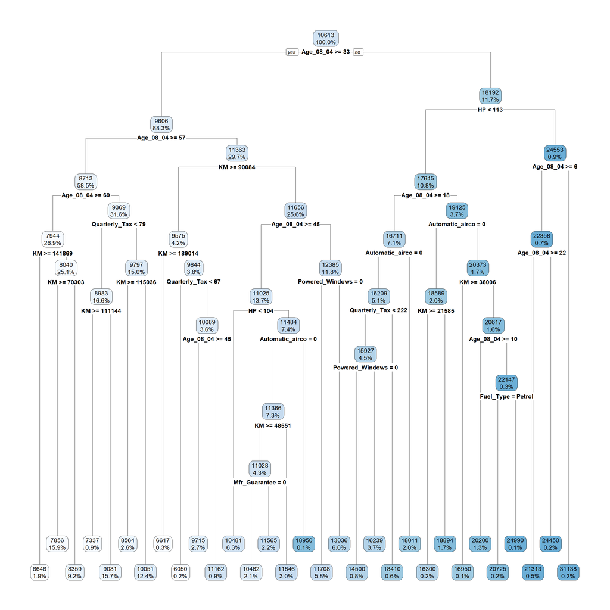

```r
rpart.plot(toyota_tree, yesno = TRUE, digits =-3) # plot the tree
```

The predicted Price at the root node is 10,613. The deviance of the root is the middle value in the printing. (source: https://bookdown.org/mpfoley1973/data-sci/regression-tree.html)

### Importance of predictors and accuracy:

### 9.3.a.i

```r
importance_var<-as.data.frame(toyota_tree$variable.importance) #we get the ranking of teh variables by importance
kable(importance_var, row.names = T,col.names="Importance")%>% kable_paper("hover", full_width = T) #built table
```

|  | Importance |
| --- | --- |
| Age_08_04 | 8450900905 |
| KM | 2534850232 |
| Automatic_airco | 2270466460 |
| Quarterly_Tax | 1048462814 |
| HP | 1043653165 |
| Guarantee_Period | 501593090 |
| CD_Player | 349705582 |
| Airco | 91726005 |
| Powered_Windows | 84385453 |
| Fuel_Type | 73783204 |
| Sport_Model | 68731066 |
| Doors | 51815095 |
| Mfr_Guarantee | 28334197 |
| Automatic | 4847133 |

### 9.3.a.ii

```r
options(scipen = 999)
tree_on_train<- predict(toyota_tree, newdata = train.df) #evaluating model on training set
tree_on_val<- predict(toyota_tree,newdata = valid.df) #evaluating model on validation set

errors<-as.data.frame(accuracy(tree_on_train, train.df$Price)) #compute accuracy measures on the model compute on the training set
rms_val<-c(accuracy(tree_on_val, valid.df$Price))#compute accuracy measures on the model computed on the validation set
accuracy_measures<-rbind(errors,rms_val) #bind the 2 together in 1 dataframe
kable(accuracy_measures,row.names = F)  %>%
  kable_paper("hover", "striped", full_width=T) # use that datframe to build a presentation table
```

| ME | RMSE | MAE | MPE | MAPE |
| --- | --- | --- | --- | --- |
| 0.00000 | 947.2256 | 746.1905 | -0.9813927 | 7.673574 |
| 50.33966 | 1247.0339 | 921.6309 | -0.8260370 | 8.919944 |

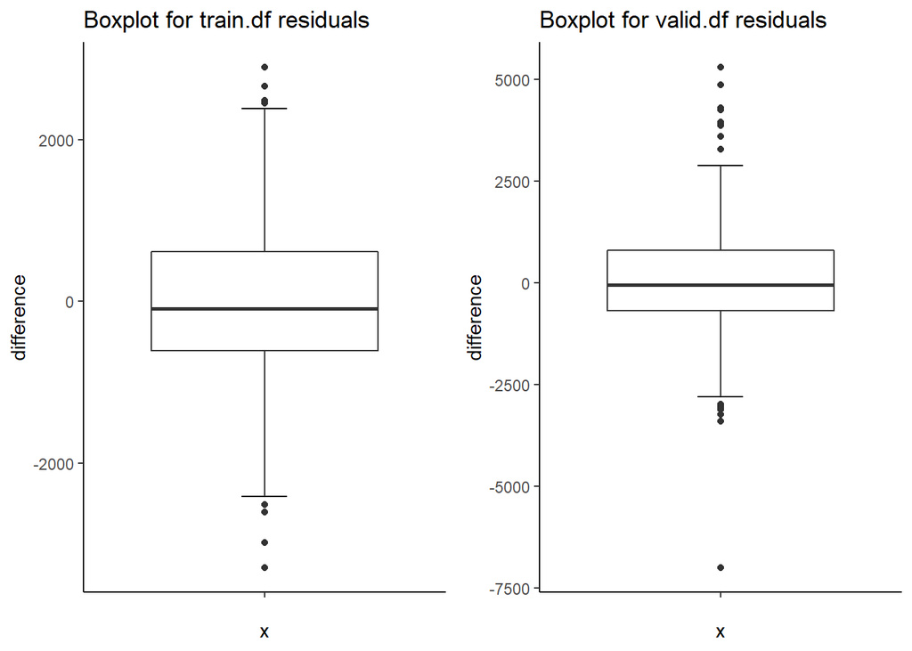

```r
                                                #to highlight the rows you are pointing at

training_residuals<- data.frame(train.df$Price- tree_on_train) #compute residuals on training set
colnames(training_residuals)[1] <- c("difference") # change column name to something more user friendly
validation_residuals<- data.frame(valid.df$Price - tree_on_val) #residuals on validation set
colnames(validation_residuals)[1]<- c("difference")

residuals_plot_train<- ggplot(training_residuals, aes(x=" ", y=difference ))+
  stat_boxplot(geom="errorbar", width=0.15)+geom_boxplot() + theme_classic()+ ggtitle("Boxplot for train.df residuals")#boxplot for residuals from training set

residuals_plot_val<- ggplot(validation_residuals, aes(x=" ", y=difference ))+
  stat_boxplot(geom="errorbar", width=0.15)+geom_boxplot() + theme_classic() + ggtitle("Boxplot for valid.df residuals") #boxplot for residuals from validation set
grid.arrange(residuals_plot_train, residuals_plot_val,  widths = c(0.5,  0.5), ncol = 2) # arrange the plots
```

When we modeled training data with maxdepth 30, which is the maximum limit for R (https://www.rdocumentation.org/packages/rpart/versions/4.1.19/topics/rpart.control), we could not achieve the 100 requested. If we look at the errata corrige version of the book that 100 is replaced with 30 , so what we achieve is our fully grown tree. The ME for the training set is 0 which given that we are looking a the tree with the lowest complexity value makes sense.On average the model on the validation set under predicts by $50.3. We look at the RMSE values, which have the same units as the outcome variable.The predictions the tree generates on the test set vary on average from the true values by an amount of $1247.

## How to re-dimension the Regression Tree:

## 9.3.a.iii

we consider the question in the errata corrige version of the book, the question is as follows: “How might we achieve better validation predictive performance at the expense of the training performance?” source: https://www.dataminingbook.com/content/errata-r-edition

As said previously, our overall error to start with for the training data is not 0, this is implied by the book because of the required 100 tree levels in the starting model.

Theoretically, a fully grown tree over fits the data, meaning it models on all the peculiar noise of the specific training set we are considering, until the prediction error is 0. When the regression tree starts modelling/splitting noise of the training set, that is when the tree will start performing very badly on the validation data. There are 2 ways of avoiding this, stopping the growing of the tree or pruning the fully grown tree.

In the first case, you can control the growth of the regression tree through the complexity parameter, which would result difficult. Another option is pruning the tree. This means getting rid of those branches (splits) that do not reduce the error rate enough. It trades off the error rate in the validation set and the size of the tree, so to model the relationship between predictors and outcome variable but not the noise. (source:https://bookdown.org/mpfoley1973/data-sci/regression-tree.html)

## Pruned Original Tree:

### 9.3.a.iv

We prune the fully grown tree we generated at the start of the exercise.

```r
options(scipen = 999)
printcp(toyota_tree, digits = 6) # we print the complexity values and their corresponding cross-validation error
```

```
##
## Regression tree:
## rpart(formula = Price ~ ., data = train.df, method = "anova",
##     minsplit = 1, minbucket = 1, cp = 0.001, maxdepth = 30)
##
## Variables actually used in tree construction:
## [1] Age_08_04       Automatic_airco Fuel_Type       HP
## [5] KM              Mfr_Guarantee   Powered_Windows Quarterly_Tax
##
## Root node error: 10190993096/861 = 11836229
##
## n= 861
##
##            CP nsplit rel error   xerror      xstd
## 1  0.64496631      0 1.0000000 1.002672 0.0864406
```

[output cut: 26 more lines]

The complexity parameter decreases by the amount of nodes generated, that is because partitions of the outcome variable gets purer and purer. Xerror is the cross validation error, the xstd is the standard deviation. Root node error is 11,836,229.

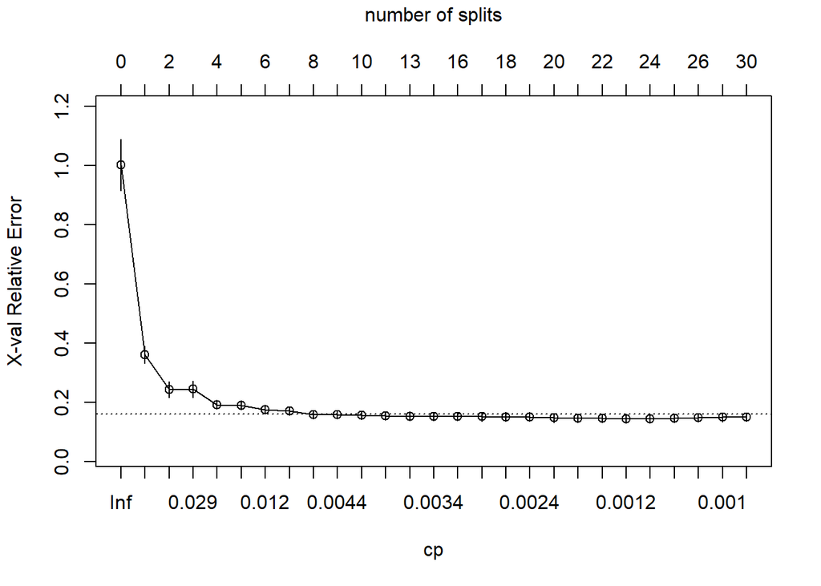

```r
plotcp(toyota_tree, upper = "splits") # we plot the progression of complexity values
```

In fact, if we plot the relationship between the cross-validation error and the complexity value, we see that it declines steadily.

```r
0.145530 + 0.0147281
```

```
## [1] 0.1602581
```

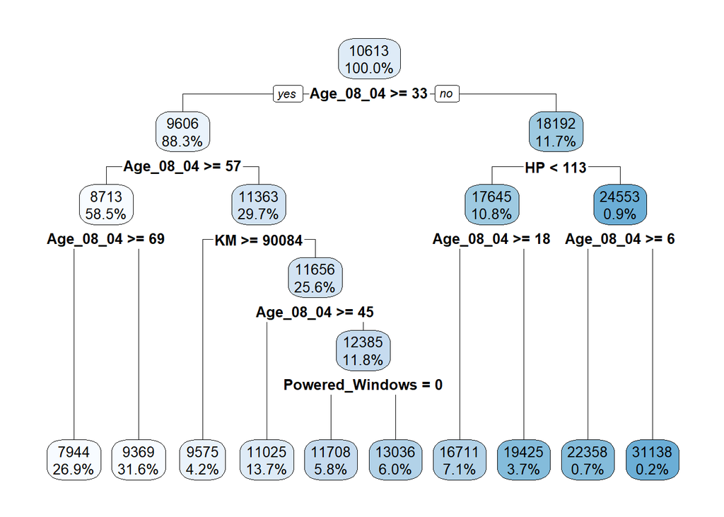

```r
set.seed(1234)
pruned_toyota_tree<- prune(toyota_tree,cp =0.00441024) #we report the Cp we found before
rpart.plot(pruned_toyota_tree, yesno = TRUE, digits = -3) #plot the regression tree
```

```r
length(pruned_toyota_tree$frame$var[pruned_toyota_tree$frame$var == "<leaf>"]) # how many end nodes
```

```
## [1] 10
```

Our Best Pruned Tree has 10 terminal nodes. The last split executed is the one for Powered Windows=0.

Its performance on the 2 sets:

```r
options(scipen = 999)
tree_on_train_p<- predict(pruned_toyota_tree, newdata = train.df) #evaluating model on training set
tree_on_val_p<- predict(pruned_toyota_tree,newdata = valid.df) #evaluating model on validation set

errors_p<-as.data.frame(accuracy(tree_on_train_p, train.df$Price)) #compute accuracy measures on the model compute on the training set
rms_val_p<-c(accuracy(tree_on_val_p, valid.df$Price))#compute accuracy measures on the model computed on the validation set
accuracy_measures_p<-rbind(errors_p,rms_val_p) #bind the 2 together in 1 data frame
kable(accuracy_measures_p,row.names = F)  %>%
  kable_paper("hover", "striped", full_width=T) # use that data frame to build a presentation table
```

| ME | RMSE | MAE | MPE | MAPE |
| --- | --- | --- | --- | --- |
| 0.00000 | 1214.566 | 923.1738 | -1.500762 | 9.385848 |
| 17.01072 | 1384.367 | 1021.8646 | -1.774958 | 10.097963 |

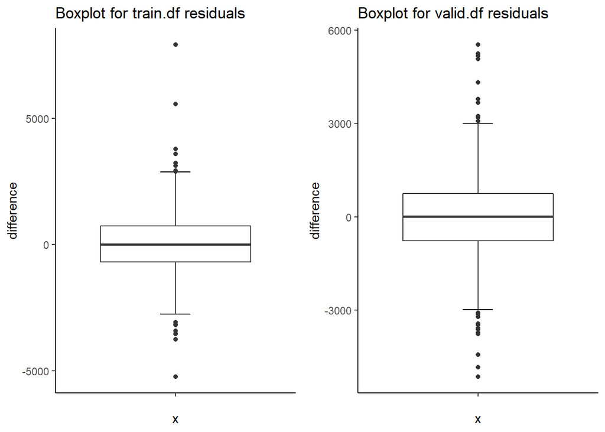

```r
                                                #to highlight the rows you are pointing at

training_residuals_p<- data.frame(train.df$Price- tree_on_train_p) #compute residuals on training set
colnames(training_residuals_p)[1] <- c("difference") # change columnname to something more user friendly
validation_residuals_p<- data.frame(valid.df$Price - tree_on_val_p) #residuals on validation set
colnames(validation_residuals_p)[1]<- c("difference")

residuals_plot_train_p<- ggplot(training_residuals_p, aes(x=" ", y=difference ))+
  stat_boxplot(geom="errorbar", width=0.15)+geom_boxplot() + theme_classic() + ggtitle("Boxplot for train.df residuals") #boxplot for residuals from training set

residuals_plot_val_p<- ggplot(validation_residuals_p, aes(x=" ", y=difference ))+
  stat_boxplot(geom="errorbar", width=0.15)+geom_boxplot() + theme_classic()+ ggtitle("Boxplot for valid.df residuals") #boxplot for residuals from validation set
#add nomi assi
grid.arrange(residuals_plot_train_p, residuals_plot_val_p,  widths = c(0.5,  0.5), ncol = 2) # arrange the plots
```

On the training set its prediction powers performs better, the RMSE is bigger on the validation set, and the variation on the errors is bigger too. But compared to the fully grown tree both RMSE have levitated, this model performs worse than the complete one but the difference in prediction performances between the 2 sets has decreased. This means that it over fits the data less, more useful to predict new data.

## Tree with default values:

### 9.3.a.iv errata corrige

we reference the errata corrige version of the book. The question is as follow: “Create a less deep tree by leaving the arguments cp, minbucket and maxdepth at their defaults. Compared to the deeper tree, what is the predictive performance on the validation set?”

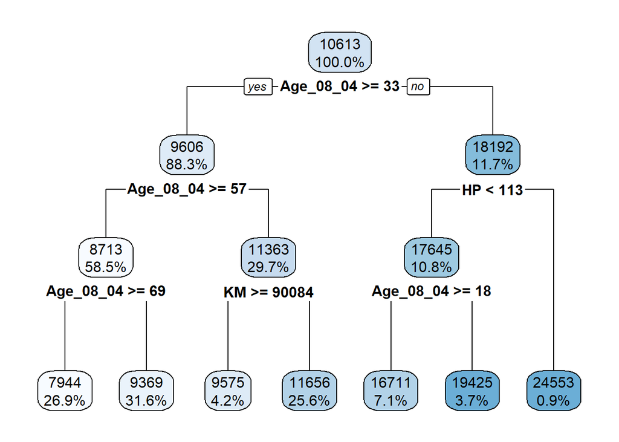

```r
set.seed(1234)
smaller_tree<- rpart(Price  ~ ., data=train.df, method= "anova")# new tree with default values
rpart.plot(smaller_tree, yesno = TRUE, digits = -3)  # we plot the new tree, and make the numbers readable
```

```r
length(smaller_tree$frame$var[smaller_tree$frame$var == "<leaf>"]) # how many end nodes
```

```
## [1] 7
```

```r
importance_var_s<-as.data.frame(smaller_tree$variable.importance ) #we make a table with te variables importance values
kable(importance_var_s, row.names = T,col.names="Importance")%>% kable_paper("hover", full_width = T) #make a table out of it
```

|  | Importance |
| --- | --- |
| Age_08_04 | 8173671592 |
| KM | 2188928495 |
| Automatic_airco | 2148659866 |
| HP | 882749946 |
| Quarterly_Tax | 788132381 |
| Guarantee_Period | 489185057 |
| CD_Player | 325932945 |
| Airco | 25206249 |
| Fuel_Type | 22325998 |
| Powered_Windows | 3287772 |

```r
options(scipen = 999)
tree_on_train_s<- predict(smaller_tree, newdata = train.df) #evaluating model on training set
tree_on_val_s<- predict(smaller_tree,newdata = valid.df) #evaluating model on validation set

errors_s<-as.data.frame(accuracy(tree_on_train_s, train.df$Price)) #compute accuracy measures on the model compute on the training set
rms_val_s<-c(accuracy(tree_on_val_s, valid.df$Price))#compute accuracy measures on the model computed on the validation set
accuracy_measures_s<-rbind(errors_s,rms_val_s) #bind the 2 together in 1 dataframe
kable(accuracy_measures_s,row.names = F)  %>%
  kable_paper("hover", "striped", full_width=T) # use that dataframe to build a presentation table
```

| ME | RMSE | MAE | MPE | MAPE |
| --- | --- | --- | --- | --- |
| 0.00000 | 1333.843 | 1006.096 | -1.644842 | 10.00541 |
| 36.64427 | 1496.501 | 1108.675 | -1.642431 | 10.67217 |

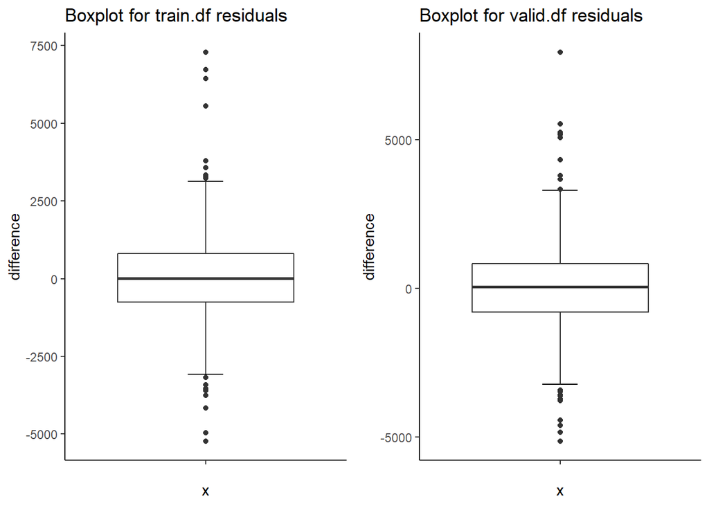

```r
                                                #to highlight the rows you are pointing at

training_residuals_s<- data.frame(train.df$Price- tree_on_train_s) #compute residuals on training set
colnames(training_residuals_s)[1] <- c("difference") # change column name to something more user-friendly
validation_residuals_s<- data.frame(valid.df$Price - tree_on_val_s) #residuals on validation set
colnames(validation_residuals_s)[1]<- c("difference")

residuals_plot_train_s<- ggplot(training_residuals_s, aes(x=" ", y=difference ))+
  stat_boxplot(geom="errorbar", width=0.15)+geom_boxplot() + theme_classic() + ggtitle("Boxplot for train.df residuals") #boxplot for residuals from training set

residuals_plot_val_s<- ggplot(validation_residuals_s, aes(x=" ", y=difference ))+
  stat_boxplot(geom="errorbar", width=0.15)+geom_boxplot() + theme_classic() + ggtitle("Boxplot for valid.df residuals") #boxplot for residuals from validation set
#add nomi assi
grid.arrange(residuals_plot_train_s, residuals_plot_val_s,  widths = c(0.5,  0.5), ncol = 2) # arrange the plots
```

The RMSE have increased, probably due to the reduced size of the tree. But compared to the other two trees the average variation of the errors magnitude is almost the same.

## Tree with Binned Price variable:

### 9.3.b

```r
df2$Price_Binned<- cut(df2$Price, breaks=20,dig.lab = -3, labels = c(1:20)) # the cut the function divides the data in 20 intervals
                                                           # dig.lab determines the number of  digits used for the break numbers
df3<-df2[,-c(1)] #we get rid of the old price variable


set.seed(1234)  # controlled random numbers, to have the same samples when we re-run the code
training_b<- sample(row.names(df3), 0.6*dim(df3)[1]) #  training set 50% of the data
validation_b<- sample(setdiff(row.names(df3), training ),  0.4*dim(df3)[1]) # validation set 30%
train.df_b<- df3[training_b,] # training set as individual data.frame
valid.df_b<- df3[validation_b,] # validation set as individual data.frame
```

We have introduced the new binned variable, and re-partitioned our new data frame.

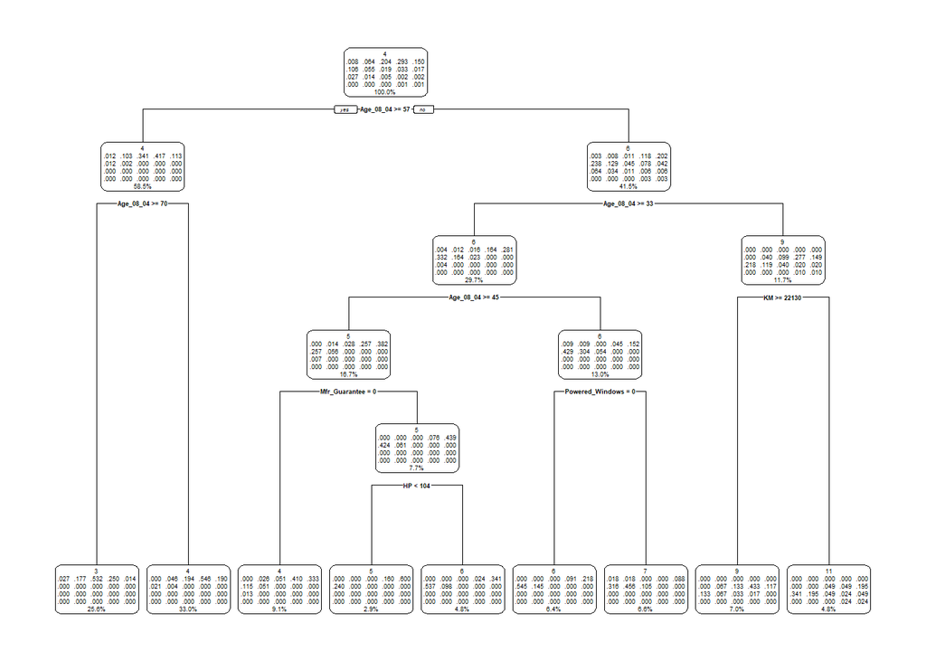

```r
set.seed(1234) #make it re-plicable
binned_tree<- rpart(Price_Binned  ~ ., data=train.df_b, method= "class") #we grow the tree for the binned outcome variable
rpart.plot(binned_tree, yesno = TRUE, digits = -3)  #we plot the tree
```

```r
length(binned_tree$frame$var[binned_tree$frame$var == "<leaf>"]) # how many end nodes
```

```
## [1] 9
```

```r
importance_var_b<-as.data.frame(binned_tree$variable.importance )
kable(importance_var_b, row.names = T,col.names="Importance")%>% kable_paper("hover", full_width = T) #make a table out of it
```

|  | Importance |
| --- | --- |
| Age_08_04 | 138.7299266 |
| KM | 47.0713690 |
| CD_Player | 25.8408276 |
| Sport_Model | 17.1755529 |
| Automatic_airco | 16.8998809 |
| Airco | 13.4355276 |
| HP | 11.5235616 |
| Mfr_Guarantee | 7.9390054 |
| Quarterly_Tax | 5.9338267 |
| Powered_Windows | 5.9215664 |
| Doors | 1.5225398 |
| Guarantee_Period | 0.4086824 |
| Fuel_Type | 0.2270061 |
| Automatic | 0.2169076 |

The tree built by using default parameters, has 9 terminal nodes.

### Performance of Binned Price tree

### 9.3.b.i

```r
pred.binned.train<- predict(binned_tree, train.df_b,type= "class") #we see how the model performs on validation set
confusionMatrix(pred.binned.train, train.df_b$Price_Binned, positive = "1")
```

```
## Confusion Matrix and Statistics
##
##           Reference
## Prediction   1   2   3   4   5   6   7   8   9  10  11  12  13  14  15  16  17
##         1    0   0   0   0   0   0   0   0   0   0   0   0   0   0   0   0   0
##         2    0   0   0   0   0   0   0   0   0   0   0   0   0   0   0   0   0
##         3    6  39 117  55   3   0   0   0   0   0   0   0   0   0   0   0   0
##         4    0  15  59 187  80  15   5   0   0   0   1   0   0   0   0   0   0
##         5    0   0   0   4  15   6   0   0   0   0   0   0   0   0   0   0   0
##         6    0   0   0   6  26  52  12   0   0   0   0   0   0   0   0   0   0
##         7    1   1   0   0   5  18  26   6   0   0   0   0   0   0   0   0   0
##         8    0   0   0   0   0   0   0   0   0   0   0   0   0   0   0   0   0
##         9    0   0   0   0   0   0   4   8  26   7   8   4   2   1   0   0   0
##         10   0   0   0   0   0   0   0   0   0   0   0   0   0   0   0   0   0
##         11   0   0   0   0   0   0   0   2   2   8  14   8   2   1   2   0   0
##         12   0   0   0   0   0   0   0   0   0   0   0   0   0   0   0   0   0
##         13   0   0   0   0   0   0   0   0   0   0   0   0   0   0   0   0   0
##         14   0   0   0   0   0   0   0   0   0   0   0   0   0   0   0   0   0
##         15   0   0   0   0   0   0   0   0   0   0   0   0   0   0   0   0   0
##         16   0   0   0   0   0   0   0   0   0   0   0   0   0   0   0   0   0
##         17   0   0   0   0   0   0   0   0   0   0   0   0   0   0   0   0   0
##         18   0   0   0   0   0   0   0   0   0   0   0   0   0   0   0   0   0
##         19   0   0   0   0   0   0   0   0   0   0   0   0   0   0   0   0   0
##         20   0   0   0   0   0   0   0   0   0   0   0   0   0   0   0   0   0
##           Reference
## Prediction  18  19  20
##         1    0   0   0
##         2    0   0   0
##         3    0   0   0
##         4    0   0   0
##         5    0   0   0
##         6    0   0   0
##         7    0   0   0
##         8    0   0   0
##         9    0   0   0
##         10   0   0   0
##         11   0   1   1
##         12   0   0   0
##         13   0   0   0
##         14   0   0   0
```

[output cut: 41 more lines]

```
## Pos Pred Value             NaN       NaN       NaN        NA        NA
## Neg Pred Value        0.995354  0.997677  0.997677        NA        NA
## Prevalence            0.004646  0.002323  0.002323         0         0
## Detection Rate        0.000000  0.000000  0.000000         0         0
## Detection Prevalence  0.000000  0.000000  0.000000         0         0
## Balanced Accuracy     0.500000  0.500000  0.500000        NA        NA
##                      Class: 18 Class: 19 Class: 20
## Sensitivity                 NA  0.000000  0.000000
## Specificity                  1  1.000000  1.000000
## Pos Pred Value              NA       NaN       NaN
## Neg Pred Value              NA  0.998839  0.998839
## Prevalence                   0  0.001161  0.001161
## Detection Rate               0  0.000000  0.000000
## Detection Prevalence         0  0.000000  0.000000
## Balanced Accuracy           NA  0.500000  0.500000
```

```r
pred.binned.val<- predict(binned_tree, valid.df_b,type= "class") #we see how the model performs on validation set
confusionMatrix(pred.binned.val, valid.df_b$Price_Binned, positive = "1")
```

```
## Confusion Matrix and Statistics
##
##           Reference
## Prediction   1   2   3   4   5   6   7   8   9  10  11  12  13  14  15  16  17
##         1    0   0   0   0   0   0   0   0   0   0   0   0   0   0   0   0   0
##         2    0   0   0   0   0   0   0   0   0   0   0   0   0   0   0   0   0
##         3    1  36  74  35   2   0   0   0   0   0   0   0   0   0   0   0   0
##         4    3   7  41 116  44  12   3   0   0   0   0   0   0   0   0   0   0
##         5    0   0   0   6   6   0   0   0   0   0   0   0   0   0   0   0   0
##         6    0   0   1   3   8  28  11   1   0   0   0   0   0   0   0   0   0
##         7    1   0   0   2   1  21  22   4   0   0   0   0   0   0   0   0   0
##         8    0   0   0   0   0   0   0   0   0   0   0   0   0   0   0   0   0
##         9    0   0   0   0   0   0   6   1  21   2   8   4   7   1   0   0   0
##         10   0   0   0   0   0   0   0   0   0   0   0   0   0   0   0   0   0
##         11   0   0   0   0   0   0   1   2   3   6   8   4   6   2   2   0   0
##         12   0   0   0   0   0   0   0   0   0   0   0   0   0   0   0   0   0
##         13   0   0   0   0   0   0   0   0   0   0   0   0   0   0   0   0   0
##         14   0   0   0   0   0   0   0   0   0   0   0   0   0   0   0   0   0
##         15   0   0   0   0   0   0   0   0   0   0   0   0   0   0   0   0   0
##         16   0   0   0   0   0   0   0   0   0   0   0   0   0   0   0   0   0
##         17   0   0   0   0   0   0   0   0   0   0   0   0   0   0   0   0   0
##         18   0   0   0   0   0   0   0   0   0   0   0   0   0   0   0   0   0
##         19   0   0   0   0   0   0   0   0   0   0   0   0   0   0   0   0   0
##         20   0   0   0   0   0   0   0   0   0   0   0   0   0   0   0   0   0
##           Reference
## Prediction  18  19  20
##         1    0   0   0
##         2    0   0   0
##         3    0   0   0
##         4    0   0   0
##         5    0   0   0
##         6    0   0   0
##         7    0   0   0
##         8    0   0   0
##         9    0   0   0
##         10   0   0   0
##         11   0   0   1
##         12   0   0   0
##         13   0   0   0
##         14   0   0   0
```

[output cut: 41 more lines]

```
## Pos Pred Value             NaN       NaN       NaN        NA        NA
## Neg Pred Value         0.97735  0.994774  0.996516        NA        NA
## Prevalence             0.02265  0.005226  0.003484         0         0
## Detection Rate         0.00000  0.000000  0.000000         0         0
## Detection Prevalence   0.00000  0.000000  0.000000         0         0
## Balanced Accuracy      0.50000  0.500000  0.500000        NA        NA
##                      Class: 18 Class: 19 Class: 20
## Sensitivity                 NA        NA  0.000000
## Specificity                  1         1  1.000000
## Pos Pred Value              NA        NA       NaN
## Neg Pred Value              NA        NA  0.998258
## Prevalence                   0         0  0.001742
## Detection Rate               0         0  0.000000
## Detection Prevalence         0         0  0.000000
## Balanced Accuracy           NA        NA  0.500000
```

The accuracy of the method is quite low, 1 out of 2 new records risks to be mis-classified, in both data-sets. This methods does not seem to be very efficient.

## Comparison:

### 9.3.b.ii & iii

So in the classification tree case, our price prediction is going to be categorical, so based on the predictors, the new record will be classified as belonging to one of the 20 price levels. For the case in which we “drop” the new record down the regression tree, we are going to get an estimate of what the price for that used car is.

```r
#we introduce the new records
options(scipen = 999, digits = 3)
corolla_nr<- data.frame (Age_08_04 = 77,KM = 117000,HP = 110,Automatic = 0,Doors = 5,Quarterly_Tax = 100,Mfr_Guarantee = 0,Guarantee_Period = 3,Airco = 1,Automatic_airco = 0,CD_Player = 0,Powered_Windows = 0, Sport_Model = 0,Tow_Bar = 1,Fuel_Type="Petrol")
# we introduce the new record

corolla_prediction_t1<- predict(smaller_tree, newdata = corolla_nr, method = "anova") #we predict on the default values tree
corolla_prediction_t2<- predict(binned_tree, newdata = corolla_nr, method="class") #we predict on the binned price tree
corolla_prediction_t3 <- predict(pruned_toyota_tree, newdata = corolla_nr, method= "anova") # we predict on the best pruned tree

corolla_prediction_t1
```

```
##    1
## 7944
```

```r
corolla_prediction_t2
```

```
##        1     2     3    4      5 6 7 8 9 10 11 12 13 14 15 16 17 18 19 20
## 1 0.0273 0.177 0.532 0.25 0.0136 0 0 0 0  0  0  0  0  0  0  0  0  0  0  0
```

```r
corolla_prediction_t3
```

```
##    1
## 7944
```

The smaller tree and the pruned one predict the same Price for the new car. For the classification tree, the highest probability is for the new record being classified within interval 3.

Because the splits are done one at the time, the trees might miss out on some relationship within the predictors, in fact we saw how th ebinning of the outcome variable brought up in importance a variable that did not seem relevant in previous models.